# Zad3_RyzykoOperacyjny

- Show All Code
- Hide All Code
- View Source

Author

Mikołaj Ziółkowski, Tomasz Sałapatek

Published

April 16, 2025

# 1 Wstęp

## 1.1 Dane

Początkowo ładujemy potrzebne biblioteki, takie jak:

- distr

- tidyr

- dplyr

- MASS

- fitdistrplus

- knitr

- kableExtra

Następnie pobieramy dane dotyczące wysokości strat brutto dla wybranego okresu oraz kategorii ryzyka. Dane zawierają kolumny takie jak rok, strata, linia. W kolumnie linia znajduje się 7 linii biznesowych: BussDistr, Com_Ban, Damage Empl_Pract, Execut_Del, External_Fr, Internal_Fr.  
Poniżej 6 pierwszych rekordów:

**Show and hide code**

```r
library(distr)
library(tidyr)
library(dplyr)
library(MASS)
library(fitdistrplus)
library(knitr)
library(kableExtra)

plik28 <- read.csv("C:/Users/mikol/OneDrive/Desktop/Modelowanie Ryzyka KiU/zad3/plik28.csv", sep=";")


plik28 <- plik28 |>
  mutate(strata = as.numeric(strata))

head(plik28)
```

```
   rok   strata      linia
1 1989 32981.05 Buss_Distr
2 1989 45033.83 Buss_Distr
3 1989 49777.81 Buss_Distr
4 1989 53346.83 Buss_Distr
5 1989 44057.32 Buss_Distr
6 1989 49705.05 Buss_Distr
```

# 2 linia Buss_Distr

## 2.1 Rozkład częstotliwości

Mowa tu o częstotliwości z którą dana kategoria ryzyka występowała na przestrzeni roku. Będziemy starali się bazie danych historycznych przyporządkować tym danym najbardziej odpowiadający im model. W taki sposób, aby móc w przyszłości przeprowadzić symulację.

W przyporządkowaniu rozkładów sugerowaliśmy się zasadą przytoczoną na wykładzie, mianowicie:  
- EX >𝐷2𝑋 rozkład dwumianowy  
- E𝑋 =𝐷2𝑋 rozkład Poissona  
- E𝑋 <𝐷2𝑋 rozkład ujemny dwumianowy

**Show and hide code**

```r
rok_BussDistr <- plik28 %>%
  filter( linia == "Buss_Distr") %>%
  group_by(rok) %>%
  summarize(liczba_zdarzen = n())

straty_BussDistr <- plik28 %>%
  filter(linia == "Buss_Distr") %>%
  group_by(rok) %>%
  summarize(straty = sum(strata, na.rm = TRUE))

BussDistr_summary <- merge(rok_BussDistr, straty_BussDistr, by = "rok")

kable(BussDistr_summary, format = "html", caption = "Podsumowanie dla liniii Buss_Distr") %>%
  kable_styling(bootstrap_options = c("striped", "hover", "condensed"), full_width = F)
```

Podsumowanie dla liniii Buss_Distr

| rok | liczba_zdarzen | straty |
| --- | --- | --- |
| 1989 | 16 | 705558.8 |
| 1990 | 13 | 623447.2 |
| 1991 | 9 | 456430.7 |
| 1992 | 20 | 996277.4 |
| 1993 | 11 | 569247.2 |
| 1994 | 4 | 146103.5 |
| 1995 | 11 | 555333.7 |
| 1996 | 10 | 479679.9 |
| 1997 | 8 | 413466.2 |
| 1998 | 6 | 312302.5 |
| 1999 | 13 | 621143.1 |
| 2000 | 7 | 356289.1 |
| 2001 | 4 | 205746.8 |
| 2002 | 7 | 311927.7 |
| 2003 | 13 | 668652.5 |
| 2004 | 7 | 328992.4 |
| 2005 | 8 | 359835.2 |
| 2006 | 15 | 795186.8 |
| 2007 | 17 | 798752.9 |
| 2008 | 8 | 406683.5 |
| 2009 | 3 | 148476.0 |
| 2010 | 11 | 577656.5 |
| 2011 | 17 | 817938.2 |
| 2012 | 11 | 538681.6 |
| 2013 | 8 | 364752.5 |
| 2014 | 6 | 325214.9 |
| 2015 | 19 | 933382.0 |
| 2016 | 12 | 590123.3 |
| 2017 | 6 | 309863.7 |
| 2018 | 13 | 624660.8 |
| 2019 | 7 | 318676.7 |
| 2020 | 18 | 901694.5 |
| 2021 | 8 | 376202.4 |
| 2022 | 13 | 614732.1 |
| 2023 | 14 | 723887.6 |

Rozkłady częstotliwości w zależności od roku oraz strat w zależności od linii biznesowych. Filtrujemy dane tylko do Buss_Distr. DLa tej linii liczymy liczbę zdarzeń operacyjnych w każdym roku oraz sumę strat rocznych.

**Show and hide code**

```r
mean_BussDistr = mean(rok_BussDistr$liczba_zdarzen)
sd_BussDistr = sd(rok_BussDistr$liczba_zdarzen)

mean_BussDistr
```

```
[1] 10.65714
```

**Show and hide code**

```r
sd_BussDistr
```

```
[1] 4.484895
```

## 2.2 Rozkład zdarzeń

Średnia i odchylenie standardowe wynoszą kolejno: 10,657 oraz 4,485. Zgodnie z zasadą przytoczoną wcześniej przyporządkowaliśmy temu rozkład ujemny dwumianowy. Dla pewności, sprawdźmy jeszcze dopasowanie funkcją “fitdistr”:

**Show and hide code**

```r
BussDistr_fit <- fitdist(rok_BussDistr$liczba_zdarzen, "nbinom")
gofstat(BussDistr_fit)
```

```
Chi-squared statistic:  3.143915
Degree of freedom of the Chi-squared distribution:  2
Chi-squared p-value:  0.2076383
Chi-squared table:
      obscounts theocounts
<= 6   6.000000   6.147408
<= 8   9.000000   5.859191
<= 11  6.000000   9.453750
<= 13  6.000000   5.073237
> 13   8.000000   8.466414

Goodness-of-fit criteria
                               1-mle-nbinom
Akaike's Information Criterion     205.6833
Bayesian Information Criterion     208.7940
```

p-value wynosi 0,208 z tego powodu nie ma podstaw do odrzucenia hipotezy i możemy uznać rozkład ujemny dwumianowy za dobrze dopasowany. Dla pewności zobaczymy to jeszcze na wykresie:

**Show and hide code**

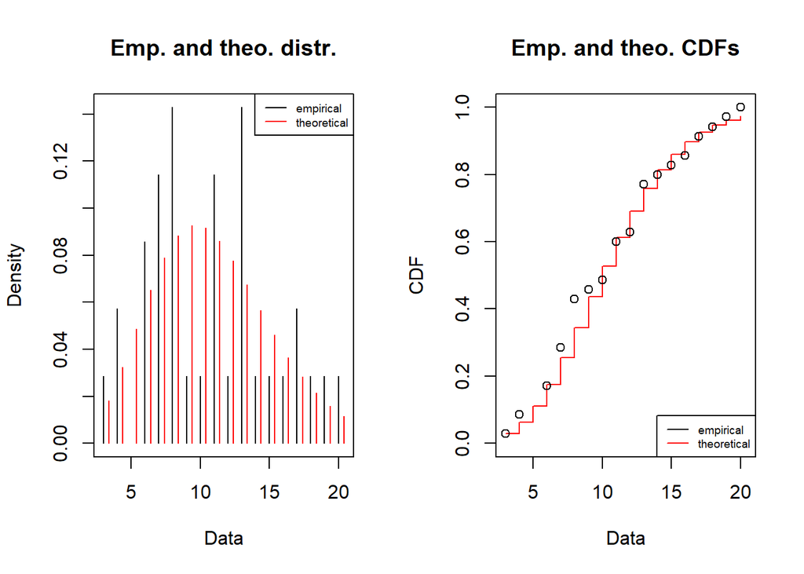

```r
plot(fitdist(rok_BussDistr$liczba_zdarzen, "nbinom"))
```

Dopasowanie zdecydowanie nie jest idealne. Wartości empiryczne rozjeżdżają się z teoretycznymi zwłaszcza na środku.

## 2.3 Rozkład strat

Ponownie, sprawdźmy dopasowanie funkcją fitdist, tym razem sprawdzamy dopasowanie rozkładu dotkliwości strat do rozkładów lnorm, exp oraz gamma. Dopasowanie metodą momentów (mme)

**Show and hide code**

```r
BussDistr2 <- fitdist(straty_BussDistr$straty, method="mme","lnorm")
BussDistr3 <- fitdist(straty_BussDistr$straty, method="mme","exp")
BussDistr4 <- fitdist(straty_BussDistr$straty, method="mme","gamma")
names_test = c("lnorm", "exp", "gamma")

Result_BussDist<-gofstat(list(BussDistr2, BussDistr3, BussDistr4), fitnames=names_test)
Result_BussDist$chisqpvalue
```

```
       lnorm          exp        gamma
1.472292e-01 1.195045e-06 1.257595e-01
```

**Show and hide code**

```r
Result_BussDist$adtest
```

```
         lnorm            exp          gamma
"not computed" "not computed" "not computed"
```

**Show and hide code**

```r
Result_BussDist$kstest
```

```
         lnorm            exp          gamma
"not rejected"     "rejected" "not rejected"
```

Zarówno rozkład lnorm jak i gamma mógłby być dobrym kandydatem. Z tego powodu, zobaczmy to na wykresie.

- Dla gammy:

**Show and hide code**

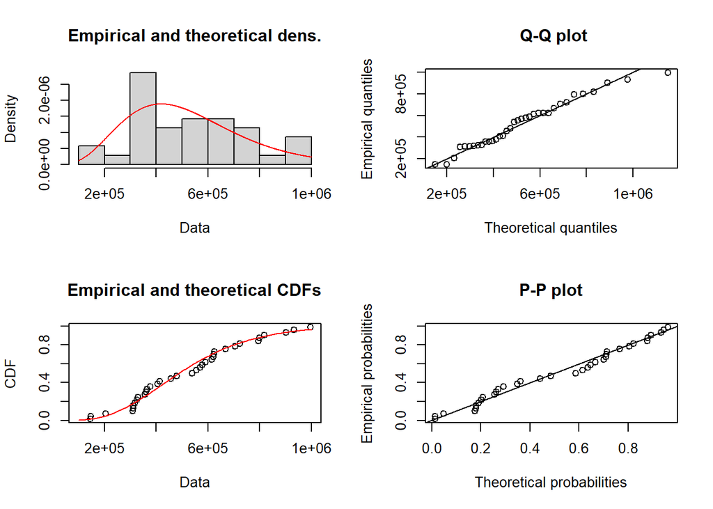

```r
plot(fitdist(straty_BussDistr$straty, "gamma"))
```

- Dla lnorm:

**Show and hide code**

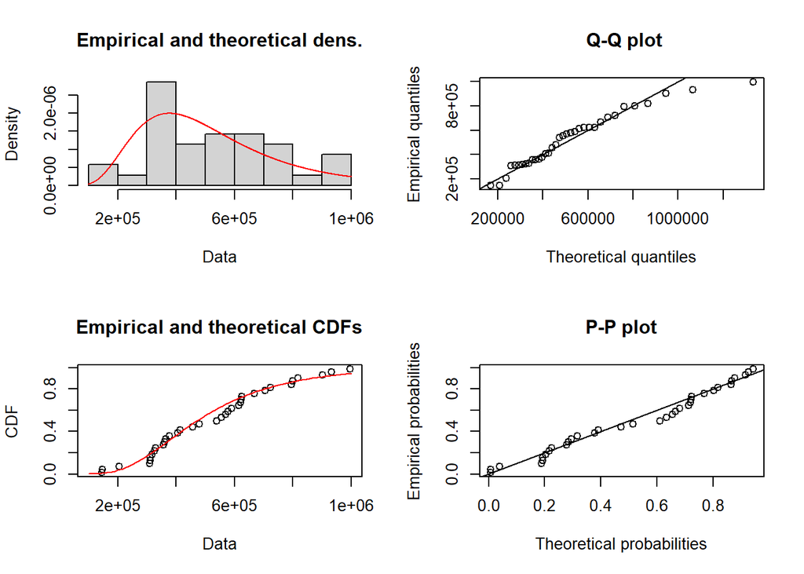

```r
plot(fitdist(straty_BussDistr$straty, "lnorm"))
```

Na wykresie możemy zobaczyć, że rozkład teoretyczny **lnorm**, nieco lepiej odzwerciedla rozkład naszyh danych, więc to jego wybierzemy do dalszych badań.